# HW5

# Loading Data and Libraries

Setup & initialization

# Correlation of attributes

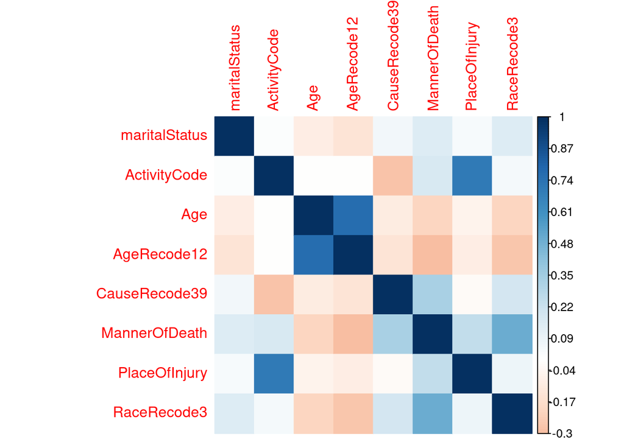

```r
death<-death[complete.cases(death), ]
death <- death %>%
  mutate(maritalStatus = case_when(
    MaritalStatus == 'D'~ 0,
    MaritalStatus == 'M'~ 1,
    MaritalStatus == 'S'~ 2,
    MaritalStatus == 'U'~ 3,
    MaritalStatus == 'W'~ 4,
  ))
death$MannerOfDeath = death$MannerOfDeath-2
death_corr_atts<<-death[c('maritalStatus','ActivityCode','Age','AgeRecode12',
               'CauseRecode39',
               'MannerOfDeath','PlaceOfInjury',
               'RaceRecode3')]

deathTable<-function(){
  return(death_corr_atts)
}
corrplot(cor(death_corr_atts),method = "color",is.corr = F,addrect = 2)
```

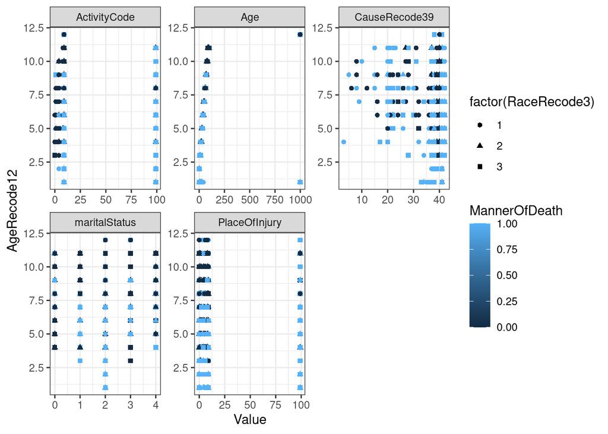

```r
death_corr_atts%>%
  gather(-AgeRecode12, -MannerOfDeath, -RaceRecode3, key = "var", value = "Value") %>%
  ggplot(aes(x = Value, y = AgeRecode12, color = MannerOfDeath, shape = factor(RaceRecode3))) +
  geom_point() +
  facet_wrap(~ var, scales = "free") +
  theme_bw()
```

```r
death_manipulated <-
  death%>%
  mutate(race = case_when(RaceRecode5==1~'White',
                          RaceRecode5==2~'Black',
                          RaceRecode5==3~'American Indian',
                          RaceRecode5==4~'Asian or Pacific Islander',
                          TRUE~'other'),
         mannerofDeath = case_when(MannerOfDeath==0~'Suicide',MannerOfDeath==1~'Homicide'),
         education = case_when(
           ((EducationReportingFlag==1 & Education2003Revision==1)
              |(EducationReportingFlag==0 & Education1989Revision<9))~'elementry',
           ((EducationReportingFlag==0 & Education1989Revision<13)
              |(EducationReportingFlag==1 & Education2003Revision<4))~'high school',
          ((EducationReportingFlag==0 & Education1989Revision<18)
              |(EducationReportingFlag==1 & Education2003Revision<9))~'college',TRUE~'Nothing'),
         mod = case_when(MethodOfDisposition=='B'~'Burial',
                                 MethodOfDisposition=='C'~'Cremation',
                                 MethodOfDisposition=='O'~'Other',TRUE~'UNKNOWN'),
         sex = case_when(
                Sex == 'M'~'Male',
                Sex == 'F'~'Female'))
```

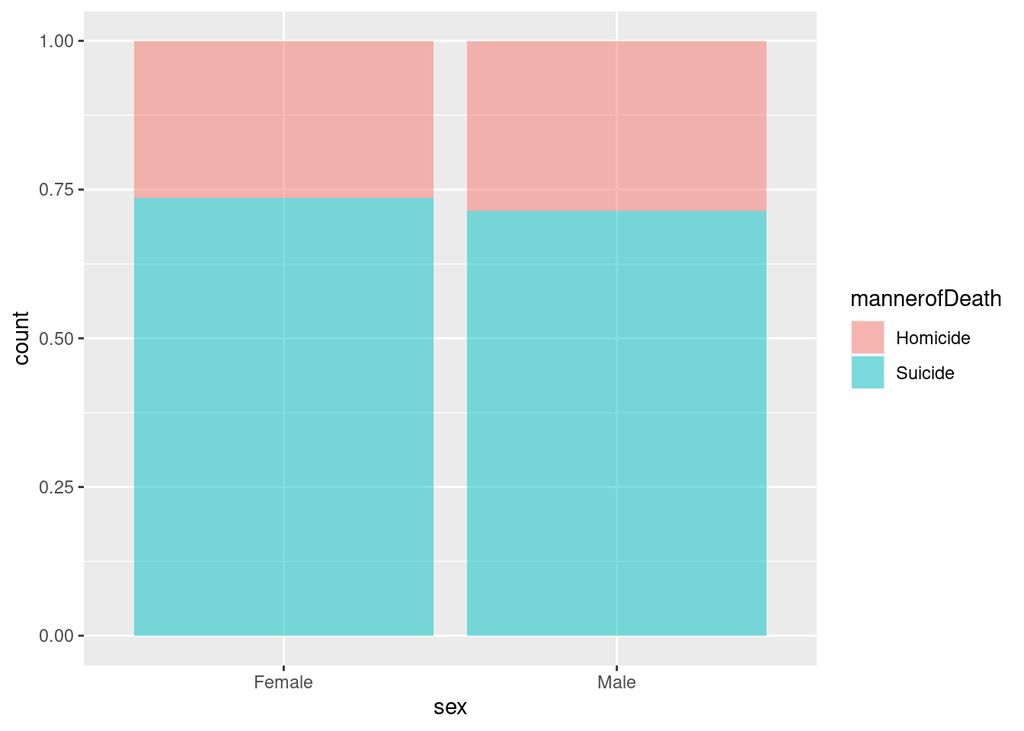

```r
# Sex
ggplot(death_manipulated)+
  geom_bar(aes(x = sex,fill = mannerofDeath),
           alpha = 0.5,position = "fill")
```

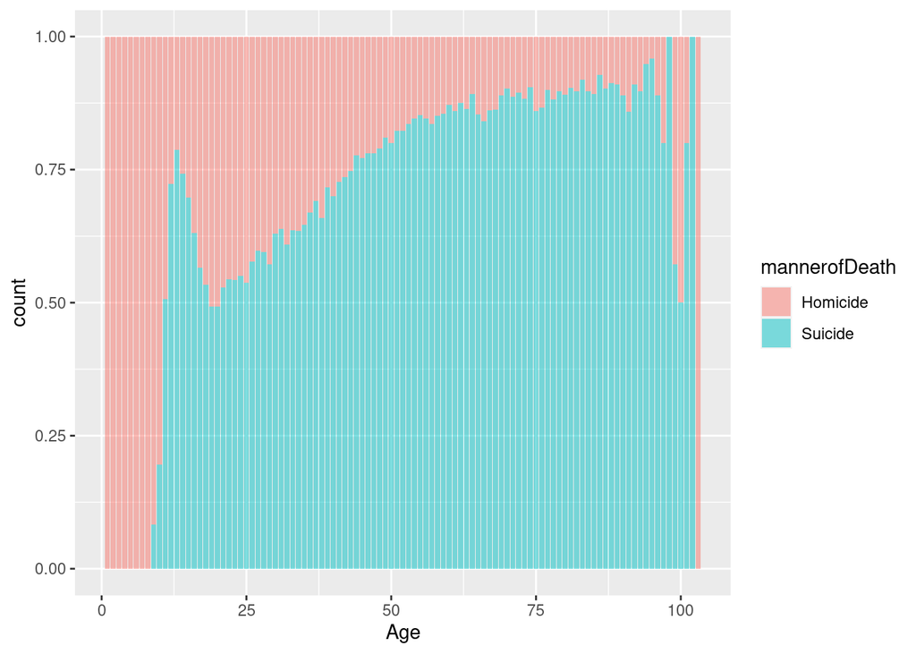

```r
# Age
ggplot(subset(death_manipulated,Age<120))+
  geom_bar(aes(x = Age,fill = mannerofDeath),
           alpha = 0.5,position = "fill")
```

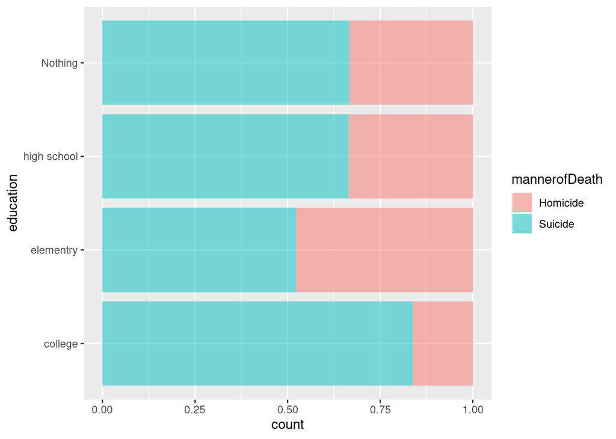

```r
# Education
ggplot(death_manipulated)+
  geom_bar(aes(y = education,fill = mannerofDeath),
           alpha = 0.5,position = "fill")
```

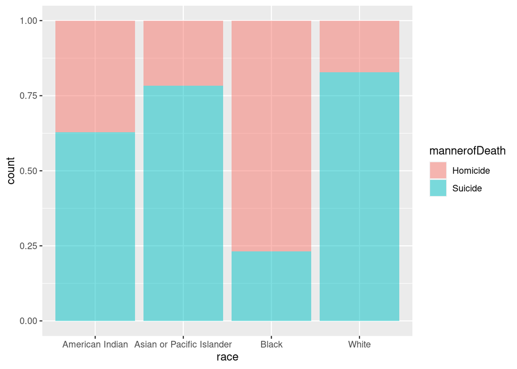

```r
# Race
ggplot(death_manipulated)+
  geom_bar(aes(x = race,fill = mannerofDeath),
           alpha = 0.5,position = "fill")
```

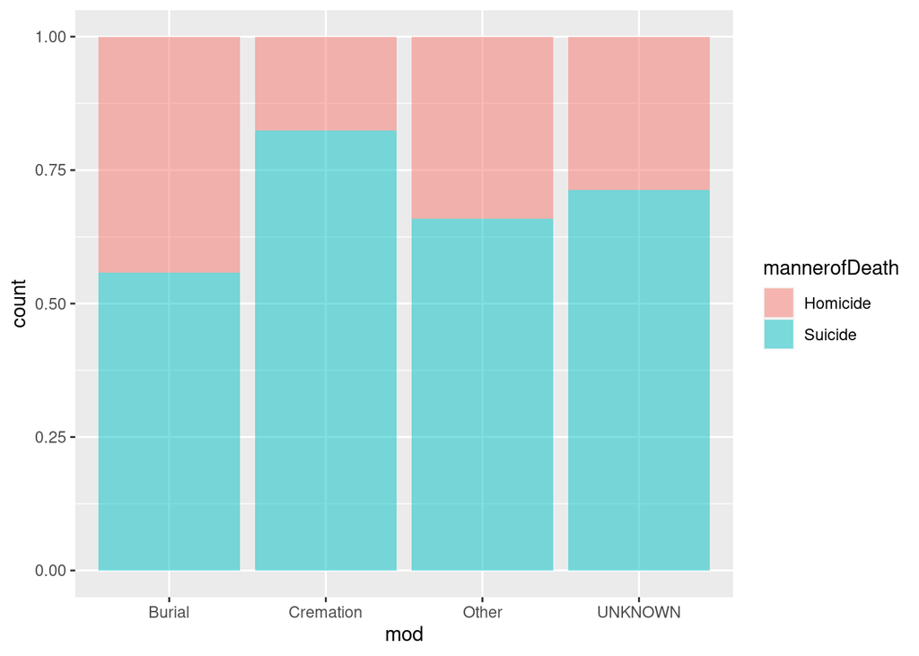

```r
# Method of disposition
ggplot(subset(death_manipulated,Age<120))+
  geom_bar(aes(x = mod,fill = mannerofDeath),
           alpha = 0.5,position = "fill")
```

# Train a Generalized Linear Model

split data into train and test by rate 0.8/0.2. family is set to binomial for logistic regression.

the first time i trained the model it faced the problem of overfitting because the mannerOfDeath was deducable from CauseRecode columns so i deleted the CauseRecodes.

# Compare Predicted Values with real Values

in this section we try to plot data in order to compare predicted vs actual manner of death based on different features. Data is manipulated in a way that falsely predited values is determined in 2 categories of “Falsely predicted as Homicide” and “Falsely predicted as Suicide”.

by comparing the plots we can realize that the model is trying to copy statistics!

```r
death.comparison=h2o.cbind(death.test,death.fit)
comparison=as.data.frame(death.comparison)
comp<-comparison%>%
  filter(Age<900)%>%
  mutate(validate=case_when(
    predict==1 & MannerOfDeath==1 ~ "Homicide",
    predict==0 & MannerOfDeath==0 ~ "Suicide",
    predict==1 & MannerOfDeath==0 ~ "Falsely predicted as Homicide",
    predict==0 & MannerOfDeath==1 ~ "Falsley predicted as Suicide",
  ))

race_coded<-comp%>%
  mutate(race_encoded=case_when(
    Race==1 ~ "White",
    Race==2 ~ "Black",
    Race==3 ~ "American Indian",
    Race==4 ~ "Chinese",
    Race==5 ~ "Japanese",
    Race==18 ~ "Asian Indian",
    Race==28 ~ "Korean",
    Race==48 ~ "Vietnamese",
    Race==58 ~ "Guamanian",
    Race==68 || Race==78 ~ "Other Asian or Pacific Islander",
    TRUE ~ "unknown"
  ))
```

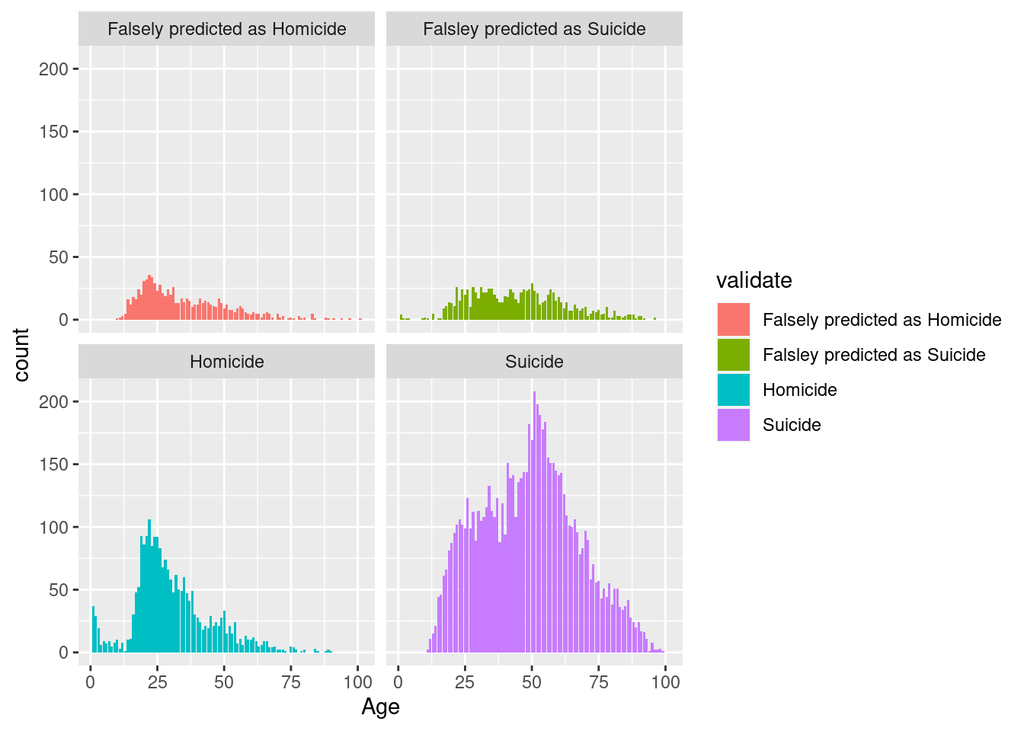

```r
#first plot
ggplot(comp,aes(x=Age,fill=validate))+
  geom_bar()+
  facet_wrap(~validate)
```

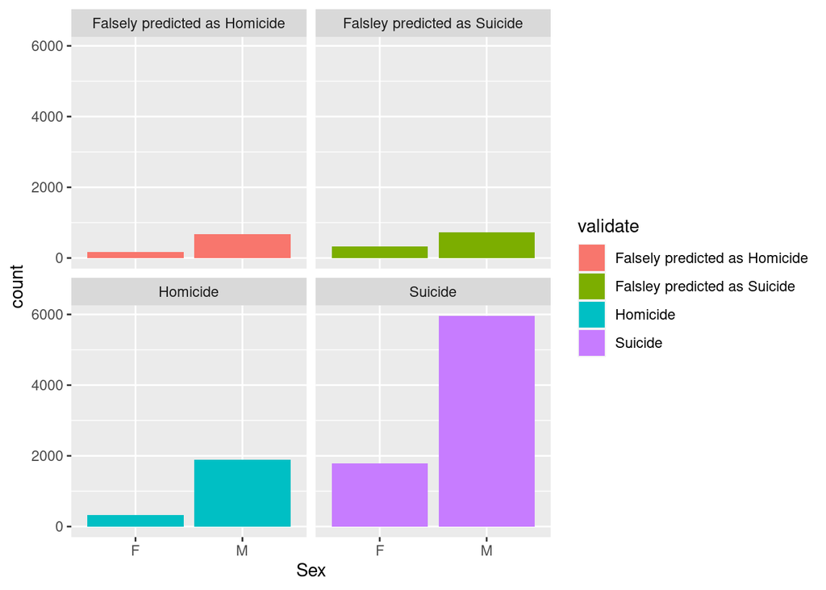

```r
#second plot
ggplot(comp,aes(x=Sex,fill=validate))+
  geom_bar()+
  facet_wrap(~validate)
```

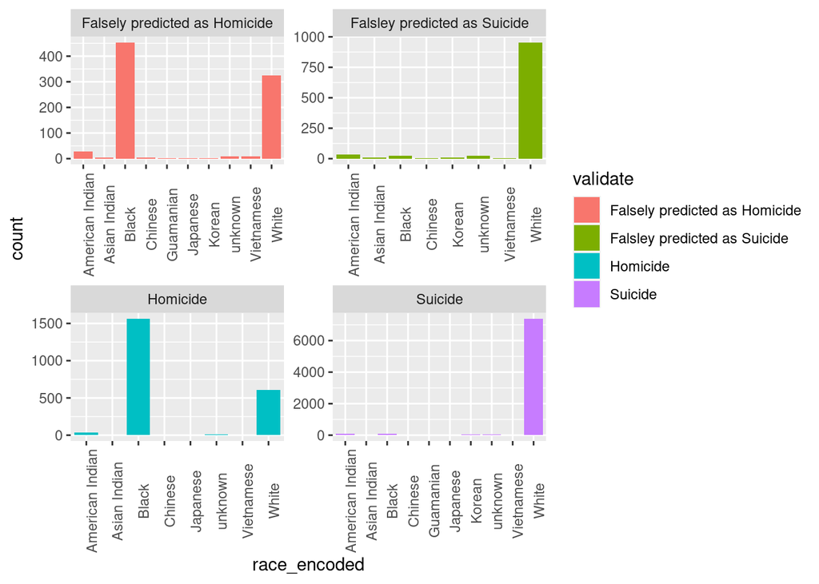

```r
#third plot
ggplot(race_coded,aes(x=race_encoded,fill=validate))+
  geom_bar()+
  facet_wrap(~validate,scales = "free")+
  theme(
    axis.text.x = element_text(angle=90)
  )
```

# Accuracy by Threshold the red dot determines the threshold in which maximum accuracy happens. the value of threshold is also printed.

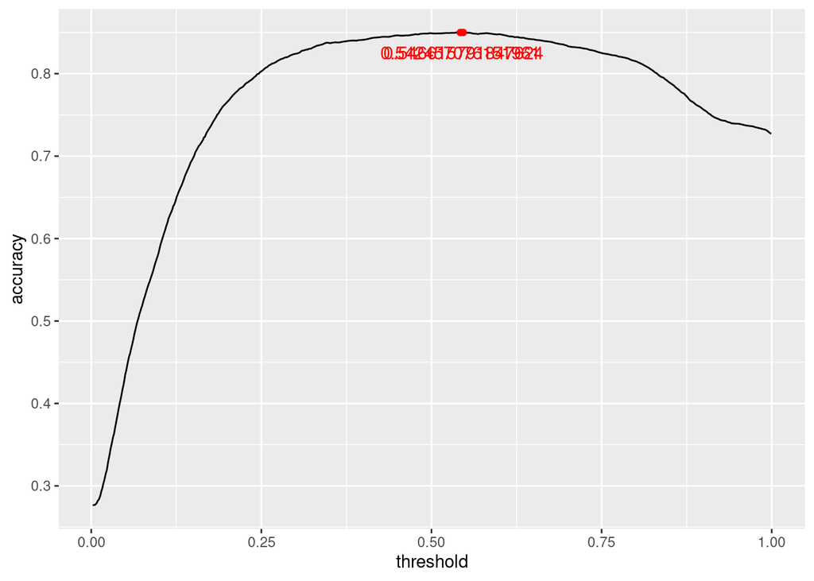

```r
perf <- h2o.performance(death.glm,death.test)
acc_pre_thresh<-h2o.accuracy(perf)
acc_pre_thresh<-acc_pre_thresh%>%mutate(co = (max(accuracy) == accuracy))
ggplot(acc_pre_thresh,aes(threshold,accuracy,label=threshold))+
  geom_line()+
  geom_point(aes(color = co))+
  geom_text(aes(color=co),vjust = 2)+
  scale_color_manual(values = c(NA, "red"))+
  theme(legend.position = "none")
```

# ROC Curve

ROC curve shows the True Positive Rate by False Positive Rate. the optimum point is where TPR is high but FPR has not yet grown.

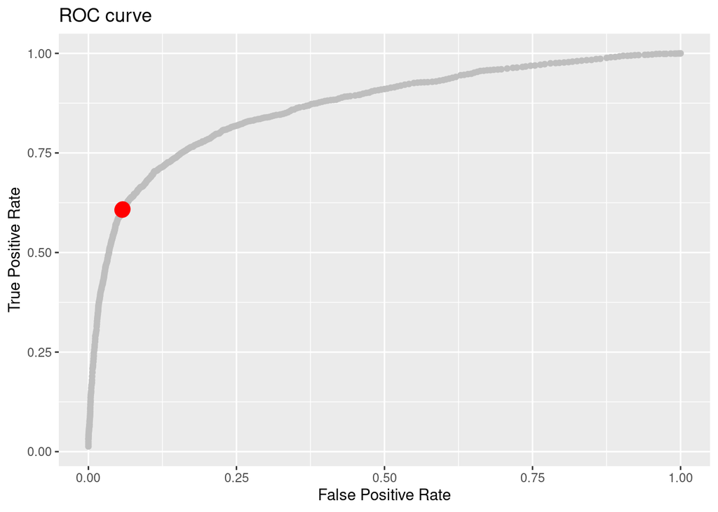

```r
max_thresh=acc_pre_thresh$threshold[acc_pre_thresh$accuracy==max(acc_pre_thresh$accuracy)]
tpr<-as.data.frame(h2o.tpr(perf))
fpr<-as.data.frame(h2o.fpr(perf))
rates<-inner_join(tpr,fpr)
rates<-rates%>%
  mutate(color=(threshold==max_thresh))

ggplot(rates,aes(fpr,tpr,label =fpr))+
  geom_point(color="gray")+
  geom_point(aes(color = color,size=8))+
  # geom_text(aes(color=color),vjust = 2)+
  scale_color_manual(values = c(NA, "red"))+
  theme(legend.position = "none")+
  labs(
    x="False Positive Rate",
    y="True Positive Rate",
    title="ROC curve"
    )
```

# building a simple Gradient Boosted Model

```r
death.hex = as.h2o(death, destination_frame= "death.hex")
death.hex["MannerOfDeath"] <- as.factor(death.hex["MannerOfDeath"] )
death.split <- h2o.splitFrame(data = death.hex, ratios = 0.8)
death.train <- death.split[[1]]
death.test <- death.split[[2]]
x = setdiff(colnames(death.hex),c("MannerOfDeath","CauseRecode358","CauseRecode113","CauseRecode39"))
y = "MannerOfDeath"

gbm<-h2o.gbm(x,y,death.train,categorical_encoding = "AUTO",stopping_metric = "logloss")
summary(gbm)
```

```
## Model Details:
## ==============
##
## H2OBinomialModel: gbm
## Model Key:  GBM_model_R_1609764288663_5
## Model Summary:
##   number_of_trees number_of_internal_trees model_size_in_bytes min_depth
## 1              50                       50               22177         5
##   max_depth mean_depth min_leaves max_leaves mean_leaves
## 1         5    5.00000         25         32    30.62000
##
## H2OBinomialMetrics: gbm
## ** Reported on training data. **
##
## MSE:  0.09937641
## RMSE:  0.3152402
## LogLoss:  0.3331944
## Mean Per-Class Error:  0.1707445
## AUC:  0.9000924
## AUCPR:  0.8372415
## Gini:  0.8001848
## R^2:  0.5079142
##
## Confusion Matrix (vertical: actual; across: predicted) for F1-optimal threshold:
##           -2    -1    Error         Rate
## -2     31089  3376 0.097954  =3376/34465
## -1      3277 10179 0.243534  =3277/13456
## Totals 34366 13555 0.138833  =6653/47921
##
## Maximum Metrics: Maximum metrics at their respective thresholds
##                         metric threshold        value idx
## 1                       max f1  0.309696     0.753693 231
## 2                       max f2  0.170770     0.784677 289
## 3                 max f0point5  0.661411     0.804767 120
## 4                 max accuracy  0.478808     0.868993 172
## 5                max precision  0.983835     1.000000   0
## 6                   max recall  0.034080     1.000000 396
## 7              max specificity  0.983835     1.000000   0
## 8             max absolute_mcc  0.389591     0.661970 201
## 9   max min_per_class_accuracy  0.202635     0.822607 274
```

[output cut: 61 more lines]

```
##   percentage
## 1   0.449010
## 2   0.111463
## 3   0.084472
## 4   0.077242
## 5   0.076555
##
## ---
##                  variable relative_importance scaled_importance percentage
## 22           MonthOfDeath           17.703976          0.001535   0.000689
## 23                AgeType            6.102042          0.000529   0.000238
## 24        BridgedRaceFlag            2.700084          0.000234   0.000105
## 25 EducationReportingFlag            1.332408          0.000116   0.000052
## 26      InfantAgeRecode22            0.691795          0.000060   0.000027
## 27   InfantCauseRecode130            0.000000          0.000000   0.000000
```

# Tuning Parametes

we first start by tuning the depth of model

```r
search_criteria <- list(strategy = "RandomDiscrete", max_models = 36, seed = 1)
hyper_params = list( max_depth = seq(1,29,2) )
my_grid <- h2o.grid("gbm", x = x, y = y,
                      grid_id = "m_grid",
                      training_frame = death.train,
                      validation_frame = death.test,
                      ntrees = 100,
                      seed = 1,
                      hyper_params = hyper_params,
                      search_criteria = search_criteria)
my_grid
## sort the grid models by decreasing AUC
sortedGrid <- h2o.getGrid("m_grid", sort_by="auc", decreasing = TRUE)
sortedGrid
## find the range of max_depth for the top 5 models
topDepths = sortedGrid@summary_table$max_depth[1:5]
minDepth = min(as.numeric(topDepths))
maxDepth = max(as.numeric(topDepths))
```

now we can tune other parameters

```r
hyper_params = list(
  max_depth = seq(minDepth,maxDepth,1),
  sample_rate = seq(0.2,1,0.01),
  col_sample_rate = seq(0.2,1,0.01),
  col_sample_rate_per_tree = seq(0.2,1,0.01),
  col_sample_rate_change_per_level = seq(0.9,1.1,0.01),
  min_rows = 2^seq(0,log2(nrow(death.train))-1,1),
  nbins = 2^seq(4,10,1),
  nbins_cats = 2^seq(4,12,1),
  min_split_improvement = c(0,1e-8,1e-6,1e-4),
  histogram_type = c("UniformAdaptive","QuantilesGlobal","RoundRobin")
)
search_criteria = list(
  strategy = "RandomDiscrete",
  max_runtime_secs = 360,
  max_models = 100,
  seed = 1234,
  stopping_rounds = 5,
  stopping_metric = "logloss",
  stopping_tolerance = 1e-3
)
grid <- h2o.grid(
  hyper_params = hyper_params,
  search_criteria = search_criteria,
  algorithm = "gbm",
  grid_id = "best_grid",
  x = x,
  y = y,
  training_frame = death.train,
  validation_frame = death.test,
  ntrees = 100,
  learn_rate = 0.05,
  learn_rate_annealing = 0.99,
  max_runtime_secs = 360,
  stopping_rounds = 5, stopping_tolerance = 1e-4, stopping_metric = "logloss",
  score_tree_interval = 10,
  seed = 1
)
sortedGrid <- h2o.getGrid("best_grid", sort_by = "logloss", decreasing = TRUE)
sortedGrid
## five best models
for (i in 1:5) {
  gbm <- h2o.getModel(sortedGrid@model_ids[[i]])
  print(h2o.auc(h2o.performance(gbm, valid = TRUE)))
}

best_model=h2o.getModel(sortedGrid@model_ids[[1]])

save(best_model,file="model.RData")
path=h2o.saveModel(best_model,"~/Documents/hesaba/HW6/model" )
```